# Relacion entre Variables

Lic. Gomez Aguirre

4/10/2023

# Contenidos

## ¿Cómo establecer una relación entre dos variables?

#### Diagrama de dispersión con ggplot

#### Correlacion

###### Correlacion de Pearson

###### Correlacon de Spearman

## Test de hipótesis

#### Igualdad de medias

#### Significatividad en la Correlación

#### Igualdad de varianza

## Regresion Simple

## Motivacion

```r
library(ggplot2)

x1=seq(100)+rnorm(100,mean = 0,sd=10)
x2=200+seq(100)+rnorm(100,mean = 2,sd=10)
p=(exp(5+0.8*x1-0.15*x2)/(1+exp(5+0.8*x1-0.15*x2)))+runif(n = 100,min = -0.5,max = 0.5)
z=seq(length(p))

for (i in seq(length(p))) {
  if (p[i]>0.5){
    z[i]=1
    }else{
      z[i]=0
  }
}
y<-200+0.75*x1-1.5*x2+0.15*z +rnorm(100,mean = 0,sd=5)
```

```r
df= cbind(x1,x2,z,y)
df=as.data.frame(df)
```

```r
summary(df)
```

```
##        x1               x2              z              y
##  Min.   :-14.76   Min.   :194.9   Min.   :0.00   Min.   :-209.29
##  1st Qu.: 27.46   1st Qu.:224.9   1st Qu.:0.00   1st Qu.:-160.83
##  Median : 49.02   Median :247.1   Median :1.00   Median :-135.08
##  Mean   : 51.57   Mean   :251.7   Mean   :0.64   Mean   :-138.60
##  3rd Qu.: 77.02   3rd Qu.:279.1   3rd Qu.:1.00   3rd Qu.:-113.28
##  Max.   :132.59   Max.   :317.0   Max.   :1.00   Max.   : -82.09
```

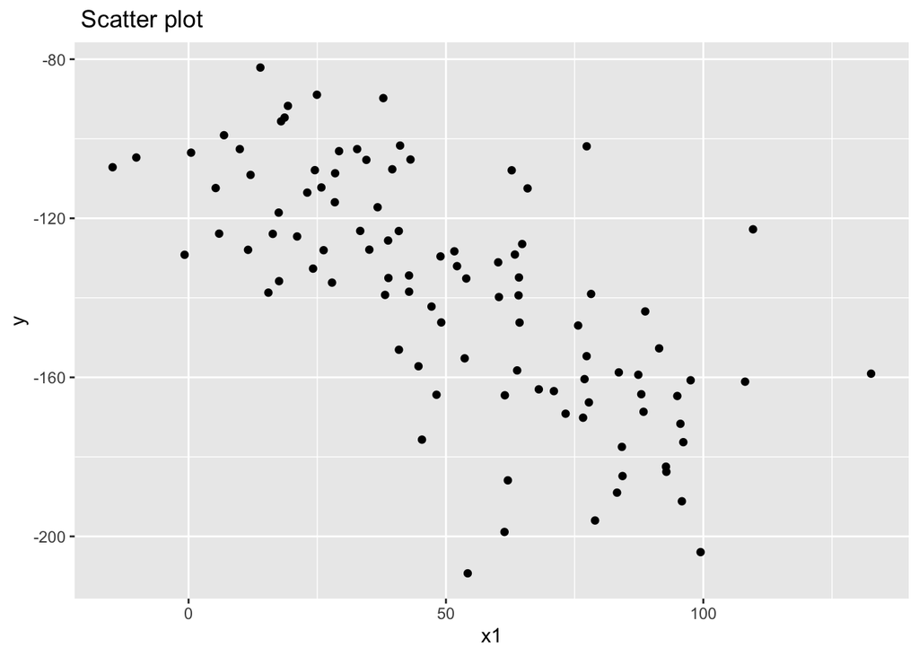

```r
ggplot(df,aes(x = x1, y = y)) + geom_point()+ ggtitle(" Scatter plot")
```

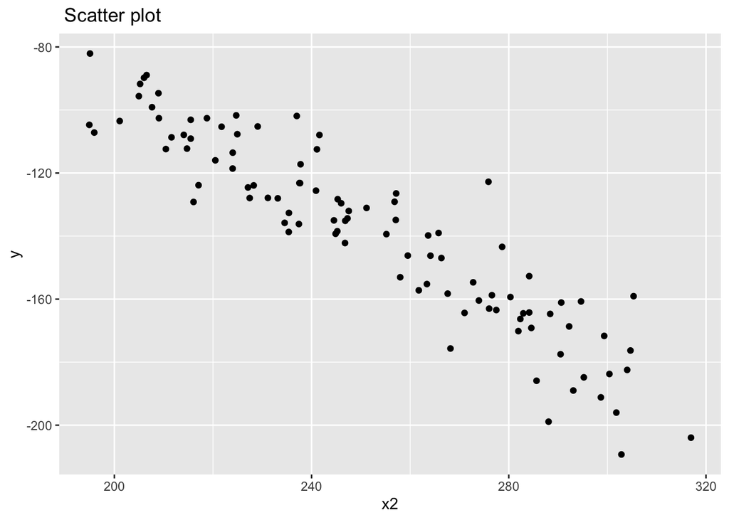

```r
ggplot(df,aes(x = x2, y = y)) + geom_point()+ ggtitle(" Scatter plot")
```

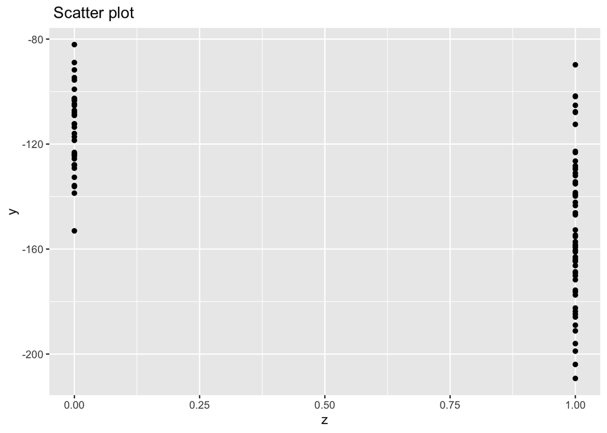

```r
ggplot(df,aes(x = z, y = y)) + geom_point()+ ggtitle(" Scatter plot")
```

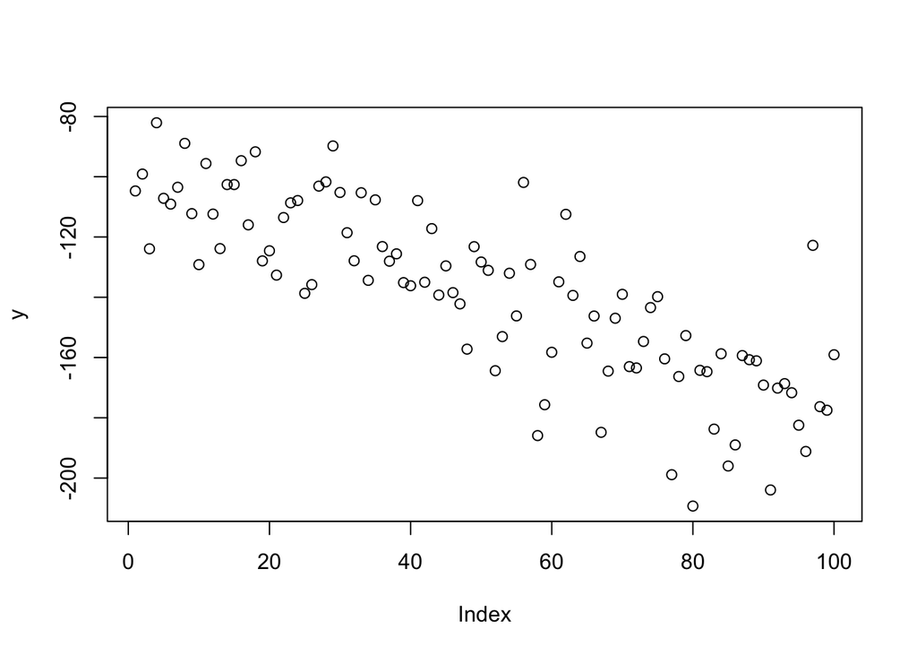

```r
plot(y)
```

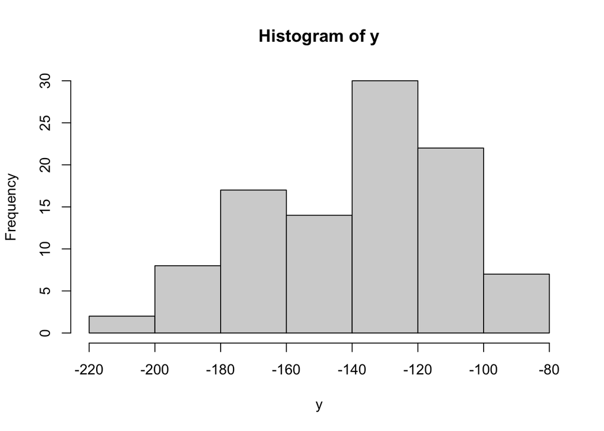

```r
hist(y)
```

## Supongamos que falta algunos datos

```r
dff=df
```

```r
dff$y[5]=NA
dff$y[50]=NA
dff$y[100]=NA
dff$y[90]=5000
```

```r
c(dff$y[5],dff$y[50],dff$y[90],dff$y[100])
```

```
## [1]   NA   NA 5000   NA
```

# Completamos los faltantes con la media

```r
media=mean(dff$y,na.rm = TRUE)
dff$y[5]=media
dff$y[50]=media
dff$y[100]=media
```

# comparamos los resultados

```r
mm=data.frame(
  "termino" = c("Media","dato_real"),
  "id_5" = c(media,df$y[5]),
  "id_50" = c(media,df$y[50]),
  "id_100" = c(media,df$y[100]))
mm
```

```
##     termino       id_5      id_50     id_100
## 1     Media  -85.52401  -85.52401  -85.52401
## 2 dato_real -107.16240 -128.30189 -159.07537
```

## Que pasa con otra variable distinta a la objetivo?

```r
table(df$z)
```

```
##
##  0  1
## 36 64
```

```r
sum(dff$z,na.rm = TRUE)/length(df$z)
```

```
## [1] 0.64
```

```r
dff$z[15]=NA
dff$z[25]=NA
dff$z[75]=NA
```

### Comparando resultados

```r
frec=sum(dff$z,na.rm = TRUE)/length(dff$z)
input=0
if (frec>0.5){
  input=1
} else{
  input=0
}
mm=data.frame(
  "termino" = c("frecuencia","inputacion","dato_real"),
  "id_15" = c(frec,input,df$z[10]),
  "id_25" = c(frec,input,df$z[25]),
  "id_75" = c(frec,input,df$z[75]))
mm
```

```
##      termino id_15 id_25 id_75
## 1 frecuencia  0.63  0.63  0.63
## 2 inputacion  1.00  1.00  1.00
## 3  dato_real  0.00  0.00  1.00
```

## Nos deberiamos preguntar que tan representativo es un input no condicionado?

## Hay alguna forma de mejorar los resultados obtenidos?

### Relacion entre variables

### Si estamos interesados en observar y medir la relación entre 2 variables numéricas.

### Por ejemplo, si queremos evaluar la relación entre:

- Las inversiones realizadas en explotaciones agrícolas y el rendimiento obtenido en dólares,
- Las horas que se dedican a estudiar una asignatura y la calificación obtenida en el examen correspondiente,
- La relación entre una medida de agresividad y la edad de los sujetos evaluados,
- La educacion y el ingreso laboral
- La cantidad de horas de estudio y el promedio de calificaciones
- Si estamos en una fábrica de piezas mecánicas y queremos analizar la relación entre la porosidad y la resistencia de las piezas.

### Cómo podemos establecer una relaciones?

#### El diagrama de dispersión nos permite observar características importantes de la relación.

#### Si observas la siguiente figura tienes cuatro ejemplos de relaciones entre varialbes:

- 1- ejemplo de relación Lineal (izquierda superior),
- 2- ejemplo de relación no lineal pero monótona (derecha superior),
- 3- ejemplo de relacion lineal exacta pero vulnerada por un outlier y,
- 4- en el último vemos que no existe realmente una relación entre “x” e “y”, sino que existe un outlier que puede confundir los resultados.

[figure not shown]

#### Caso 1: el primer caso muestra una relacion positiva en lo que podria ser un conjunto de datos bivariado. Cada punto es un par ordenado de las dos variables, como puede verse el conjunto de pares ordenado no estan alineados en forma exacta sobre una linea recta. Si un aumento en la variable del eje de ordenadas (llamemosle “y”) habitualmente, se asocia con un aumento en la variable del eje de abscisas (llamemosle “x”), entonces tenemos una relacion positiva.

## Correlacion

#### La forma de medir el grado de asociacion entre las variables, mas alla del analisis grafico, es por medio de la correlacion.

#### Antes de seguir avanzando, pensemos en la formula de la correlacion (como medida de asociacion lineal entre variables). El coeficiente de correlacion de Pearson mide el grado de asociasion lineal etre un par de variables.

[figure not shown]

### Es el método de correlación más utilizado pero asume que:

- 1- la tendencia debe ser de tipo lineal.
- 2- no existen valores atípicos (outliers).
- 3- las variables deben ser numéricas. Si las variables son de tipo ordinal (como las preguntas en escala de likert), no podremos aplicar la correlación de Pearson.
- 4- tenemos suficientes datos(algunos autores recomiendan tener más de 30 puntos u observaciones).

### El coeficiente de correlacion de Spearman mide relaciones monotonas.

[figure not shown]

[figure not shown]

### Ejemplo: #

[figure not shown]

### El coeficiente de correlación de Spearman es recomendable utilizarlo cuando:

- los datos presentan valores extremos, ya que dichos valores afectan mucho el coeficiente de correlación de Pearson, o
- ante distribuciones no normales.

# Correlacion ante elementos estocasticos

### Si los puntos se alejan de esa linea imaginaria, la asociacion lineal entre las variables disminuye, disminuye. Veamos un ejemplo:

[figure not shown]

### Para interpretar qué tan fuerte es la correlación podemos utilizar el criterio de Cohen de 1988, quién para valores absolutos indica que valores entre:

#### Entre 0.1 - 0.3 representan un efecto pequeño,

#### Entre 0.3 - 0.5 un efecto medio y

#### >= .5 un efecto grande.

#### Veamos como funciona la formula de correlacion como medida de asociacion (lineal)

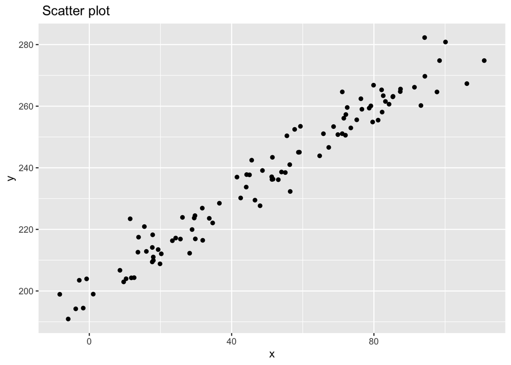

```r
library(ggplot2)

x<-seq(100)+rnorm(100,mean = 0,sd=10)

y<-200+0.75*x+rnorm(100,mean = 0,sd=5)

df= cbind(x,y)
df=as.data.frame(df)

ggplot(df,aes(x = x, y = y)) + geom_point()+ ggtitle(" Scatter plot")
```

#### Veamos diferentes situaciones

```r
cor(x,y)
```

```
## [1] 0.9758856
```

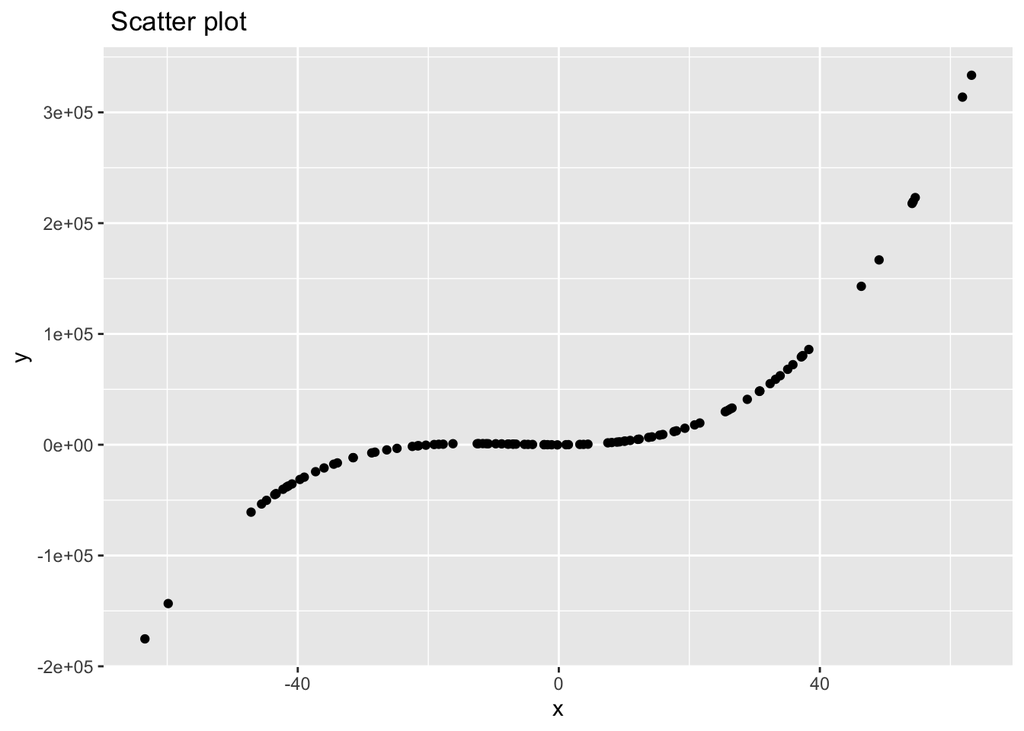

```r
x<-seq(-50,49)+rnorm(100,mean = 0,sd=10)

y<-10*x+20*x^2+x^3-8+rnorm(100,mean = 0,sd=50)

df= cbind(x,y)
df=as.data.frame(df)

ggplot(df,aes(x = x, y = y)) + geom_point()+ ggtitle(" Scatter plot")
```

### Pongamos a prueba la asociacion lineal

```r
cor(x,y)
```

```
## [1] 0.818585
```

```r
cor(x, y, method = "spearman")
```

```
## [1] 0.95988
```

#### El grafico tres otra situacion, existe uno o varios outier en la muestra, como afecta esto a la correlacion? recuerde que la mayoria de las bases de datos con las que nos enfrentamos tienen mucho ruido.

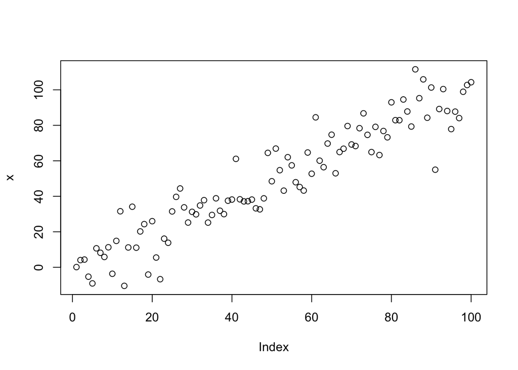

```r
x1<-seq(50)+rnorm(50,mean = 0,sd=10)
x2=rep(51)+rnorm(1,mean = 0,sd=10)
x3<-seq(52,100)+rnorm(49,mean = 0,sd=10)
x=c(x1, x2,x3)
plot(x)
```

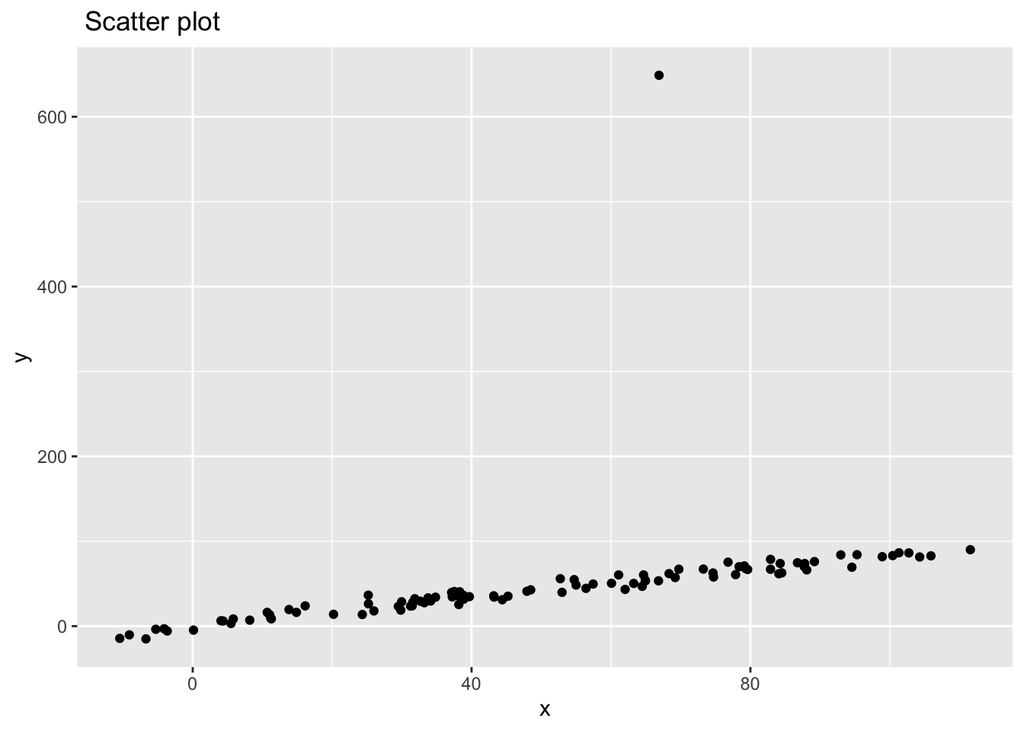

```r
y1<-2+0.8*x1+rnorm(length(x1),mean = 0,sd=5)
y2<-20+8*x2+rnorm(length(x2),mean = 100,sd=10) ### Aca se introduce el outlier
y3<-2+0.8*x3+rnorm(length(x3),mean = 0,sd=5)
y=c(y1,y2,y3)
df= cbind(x,y)
df=as.data.frame(df)

ggplot(df,aes(x = x, y = y)) + geom_point()+ ggtitle(" Scatter plot")
```

### Piensen un segundo por que razon podria ocurrir un valor extremo como el que estamos incorporando (luego lo analizaremos):

- Un error de tipeo
- Una coma mal puesta
- Hay un individuo que se comporta diferente al resto
- Por que podria ocurrir que un individuo no se comporte como el resto
- Es una medida de nuestra ignorancia?

```r
cor(x,y)
```

```
## [1] 0.4417022
```

```r
cor(x, y, method = "spearman")
```

```
## [1] 0.9711251
```

### Son estas correlaciones iguales?

#### El paquete corplot tiene graficas para analizar la correlacion. el analisis con dos varialbes no requiere demasiado, pero cuando tienen que correlacionar muchas variables, esto comienza a ser relevante.

```r
library("corrplot")
```

```r
data(mtcars)
head(mtcars)
```

```
##                    mpg cyl disp  hp drat    wt  qsec vs am gear carb
## Mazda RX4         21.0   6  160 110 3.90 2.620 16.46  0  1    4    4
## Mazda RX4 Wag     21.0   6  160 110 3.90 2.875 17.02  0  1    4    4
## Datsun 710        22.8   4  108  93 3.85 2.320 18.61  1  1    4    1
## Hornet 4 Drive    21.4   6  258 110 3.08 3.215 19.44  1  0    3    1
## Hornet Sportabout 18.7   8  360 175 3.15 3.440 17.02  0  0    3    2
## Valiant           18.1   6  225 105 2.76 3.460 20.22  1  0    3    1
```

```r
M <- cor(mtcars)  #permite ejecutar una matriz de correlación
```

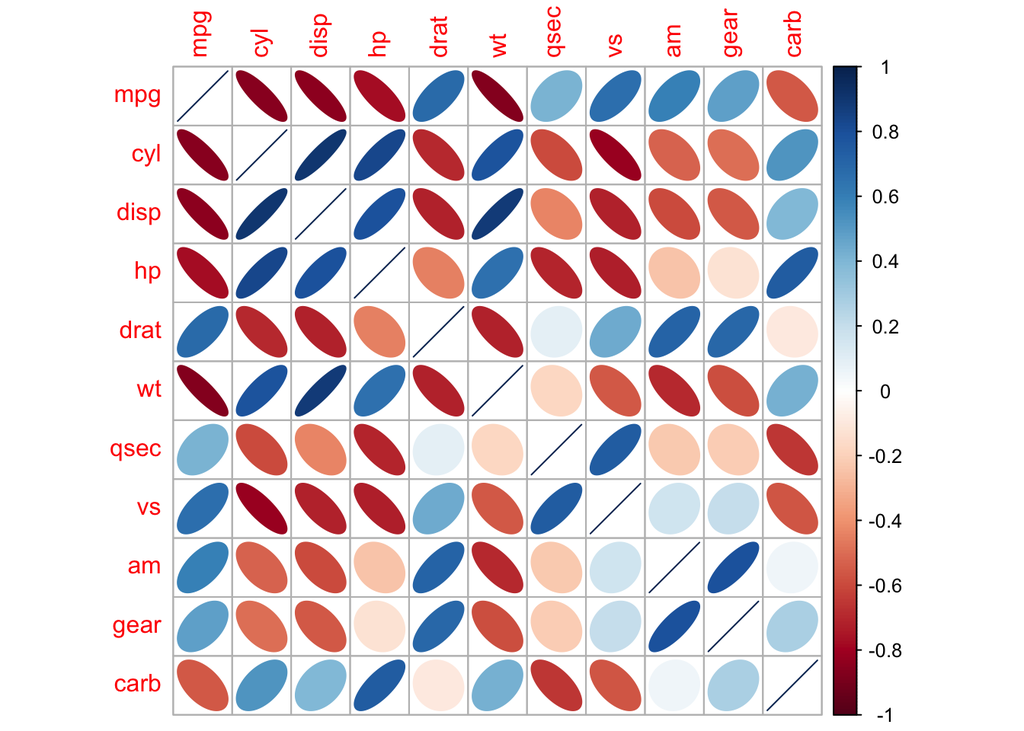

```r
corrplot(M, method = "ellipse")
```

```r
cor(mtcars$mpg, mtcars$am)
```

```
## [1] 0.5998324
```

```r
cor(x, y, method = "spearman")
```

```
## [1] 0.9711251
```

```r
cor(mtcars)
```

```
##             mpg        cyl       disp         hp        drat         wt
## mpg   1.0000000 -0.8521620 -0.8475514 -0.7761684  0.68117191 -0.8676594
## cyl  -0.8521620  1.0000000  0.9020329  0.8324475 -0.69993811  0.7824958
## disp -0.8475514  0.9020329  1.0000000  0.7909486 -0.71021393  0.8879799
## hp   -0.7761684  0.8324475  0.7909486  1.0000000 -0.44875912  0.6587479
## drat  0.6811719 -0.6999381 -0.7102139 -0.4487591  1.00000000 -0.7124406
## wt   -0.8676594  0.7824958  0.8879799  0.6587479 -0.71244065  1.0000000
## qsec  0.4186840 -0.5912421 -0.4336979 -0.7082234  0.09120476 -0.1747159
## vs    0.6640389 -0.8108118 -0.7104159 -0.7230967  0.44027846 -0.5549157
## am    0.5998324 -0.5226070 -0.5912270 -0.2432043  0.71271113 -0.6924953
## gear  0.4802848 -0.4926866 -0.5555692 -0.1257043  0.69961013 -0.5832870
## carb -0.5509251  0.5269883  0.3949769  0.7498125 -0.09078980  0.4276059
##             qsec         vs          am       gear        carb
## mpg   0.41868403  0.6640389  0.59983243  0.4802848 -0.55092507
## cyl  -0.59124207 -0.8108118 -0.52260705 -0.4926866  0.52698829
## disp -0.43369788 -0.7104159 -0.59122704 -0.5555692  0.39497686
## hp   -0.70822339 -0.7230967 -0.24320426 -0.1257043  0.74981247
## drat  0.09120476  0.4402785  0.71271113  0.6996101 -0.09078980
## wt   -0.17471588 -0.5549157 -0.69249526 -0.5832870  0.42760594
## qsec  1.00000000  0.7445354 -0.22986086 -0.2126822 -0.65624923
## vs    0.74453544  1.0000000  0.16834512  0.2060233 -0.56960714
## am   -0.22986086  0.1683451  1.00000000  0.7940588  0.05753435
## gear -0.21268223  0.2060233  0.79405876  1.0000000  0.27407284
## carb -0.65624923 -0.5696071  0.05753435  0.2740728  1.00000000
```

### Por que haria una comparacion entre dos correlaciones

## Ejemplo:

### Muestra1: Corr(mtcars$am,mtcars$gear)

### Muestra2: Corr(mtcars$am,mtcars$gear)

### Son estas dos correlaciones iguales, que implicaria que lo sean o que no lo sean?

## Ejemplo (precios)

### carguemos unos datos

```r
library(readxl)
preciost <- read_excel("/Users/azulmakk/Desktop/Analitica Descriptiva/Clases/precios.xlsx", 2) # Este es el set de datos originales tiene algunos faltantes producto de Covid-19 y titulos muy largos
precios <- read_excel("/Users/azulmakk/Desktop/Analitica Descriptiva/Clases/precios.xlsx", 1) # esta base es la misma que la anterior pero sacando los missings, cortando la muestra a los valores existentes y asignandole un indice a los titulos
colnames(preciost)
```

```
##  [1] "Pan y cereales"
##  [2] "Carnes y derivados"
##  [3] "Leche, productos lácteos y huevos"
##  [4] "Aceites, grasas y manteca"
##  [5] "Frutas"
##  [6] "Verduras, tubérculos y legumbres"
##  [7] "Azúcar, dulces, chocolate, golosinas, etc."
##  [8] "Café, té, yerba y cacao"
##  [9] "Aguas minerales, bebidas gaseosas y jugos"
## [10] "Bebidas alcohólicas"
## [11] "Tabaco"
## [12] "Prendas de vestir y materiales"
## [13] "Calzado"
## [14] "Alquiler de la vivienda"
## [15] "Mantenimiento y reparación de la vivienda"
```

[output cut: 21 more lines]

```r
M <- cor(precios, method = c("spearman"), use = "complete.obs")  #permite ejecutar una matriz de correlación
```

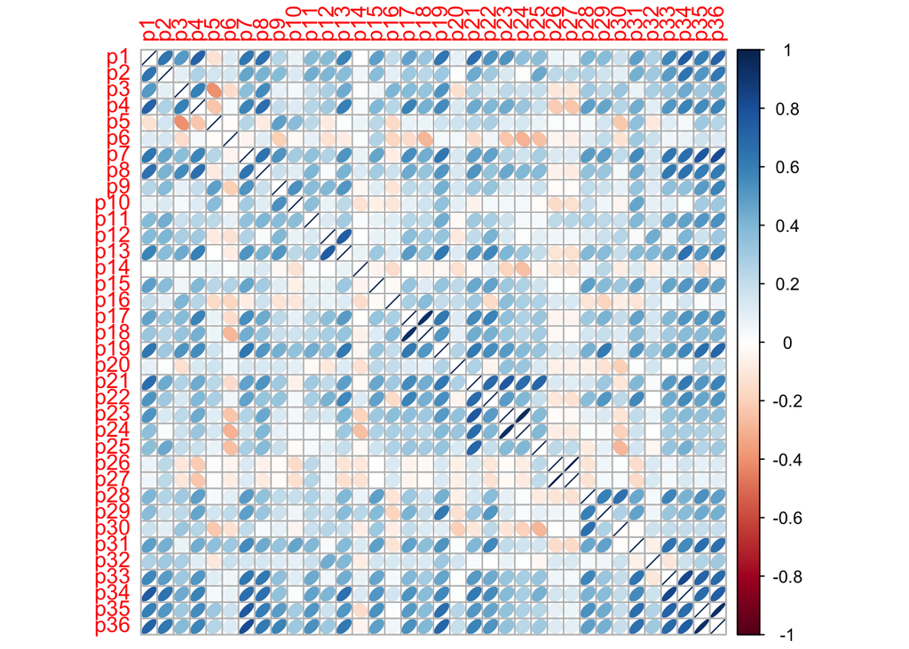

```r
corrplot(M, method = "ellipse")
```

### 1) Que le sugiere el grafico?

### 2) Que se podria hacer?

## Ejercicios

```r
Notas <- read_excel("/Users/azulmakk/Desktop/Analitica Descriptiva/Clases/Ejercicio.xlsx")
head(Notas, 18)
```

```
## # A tibble: 18 × 4
##     `N°` Estudiante Matemática Estadística
##    <dbl> <chr>           <dbl>       <dbl>
##  1     1 Dyana            10           3.5
##  2     2 Elizabeth         9           1
##  3     3 Mario             8           6
##  4     4 Orlando           8           8
##  5     5 Mathías           7           7
##  6     6 Benjamín          6          10
##  7     7 Segundo           6           4
##  8     8 Bertha            6           3.5
##  9     9 Alberto           5           1
## 10    10 Victoria          4           3
## 11    11 Sandra            4           9
## 12    12 Ximena            3           5
## 13    13 Darío             3           2.5
## 14    14 Santiago          2           0.7
## 15    15 José              1           2
## 16    16 Tomás             0.7         1.5
## 17    17 Paola             0.5         2.5
## 18    18 Kevin             0.5         0.5
```

### Sobre el set de datos Notas

#### a- Realice un scatter plot

#### b- Calcule el coeficiente de Correlacion de Spearman

#### c- Calcule el coeficiente de Correlacion de Pearson

#### d- Compare los resultados. busque en la bibliografia y de una explicacion de estas diferencias

## Test de hipótesis

#### Igualdad de medias

#### Significatividad en la Correlación

#### Independencia de variables

## Que es un test de hipotesis?

### Un test de hipotesis es una herramienta que permite tomar una decision sobre la veracidad de una presumcion respecto de un evento o hecho especifico.

[figure not shown]

### Estas dos explicaciones tienen nombres: la primera se llama hipótesis nula; la segunda es la hipótesis alternativa.

### Analicemos este problema:

### Supongamos que la variable aleatoria de interés X tiene una media μ y una varianza σ2 conocida. Asumimos que X tiene distribución normal, es decir X~N(μ,σ2)

### El estadistico muestral tiene una distribucion

[figure not shown]

### Supongamos ahora que queremos determinar si el valor poblacional es igual a un valor especifico con la unica informacion con la que contamos, que en definitiva es una muestra. Por lo tanto formulamos una hipotesis nula respecto del valor especifico.

[figure not shown]

### Recuerde que como estamos tomando una decisión basados en el valor de un estadístico podemos cometer dos tipos de errores:

- rechazar H0 cuando ésta es verdadera,
- aceptar H0 cuando ésta es falsa,

### El primero se conoce como error de tipo I, y el segundo como error de tipo II.

### Para calcular estas probabilidades debemos conocer la distribución del estadístico de prueba en el caso de ser H0 verdadera, es decir debemos conocer la distribución del estadístico de prueba “bajo H0”.

### Si la hipotesis nula de Mu=Muo es verdadera, entonces:

[figure not shown]

### por lo tanto el estadistico z es:

[figure not shown]

#

[figure not shown]

## Ejemplo Diferencia de media

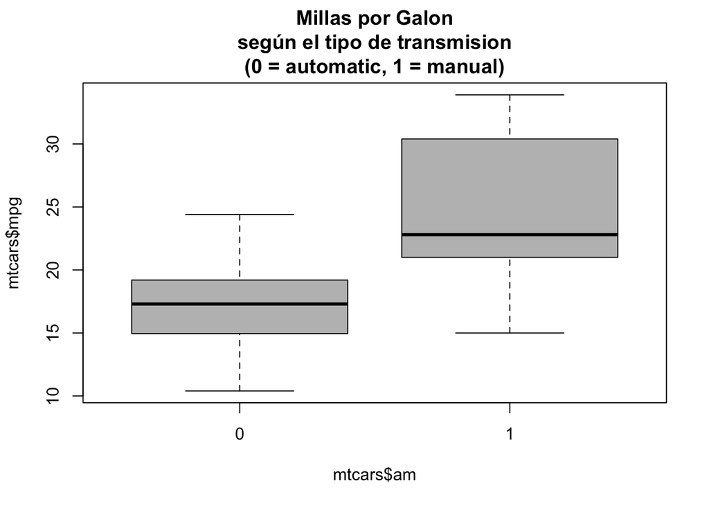

```r
boxplot(mtcars$mpg ~ mtcars$am, col = "gray",
        main = "Millas por Galon\nsegún el tipo de transmision\n(0 = automatic, 1 = manual)")
```

# ### calculemos las estadiscitas asociadas a las millas por galon y el tipo de transmision

```r
media<-tapply(mtcars$mpg, INDEX = mtcars$am, FUN = mean)
sdv<-tapply(mtcars$mpg, INDEX = mtcars$am, FUN = sd)
media
```

```
##        0        1
## 17.14737 24.39231
```

```r
sdv
```

```
##        0        1
## 3.833966 6.166504
```

### PREGUNTA 1

```r
Z=(17.14-0)/(3.833/(19)^0.5)
abs(Z)
```

```
## [1] 19.49166
```

```r
qt(0.975,18)
```

```
## [1] 2.100922
```

# Comparación de la media muestral con la media poblaional

```r
test <- t.test(mtcars$mpg, mu=17)

print(test)
```

```
##
##  One Sample t-test
##
## data:  mtcars$mpg
## t = 2.9008, df = 31, p-value = 0.006788
## alternative hypothesis: true mean is not equal to 17
## 95 percent confidence interval:
##  17.91768 22.26357
## sample estimates:
## mean of x
##  20.09062
```

### si las varaibles son independientes y la cantidad de observacioens es menor a 30

[figure not shown]

```r
test <- t.test(mtcars$mpg,mtcars$mpg) # Prueba t de Student

print(test)
```

```
##
##  Welch Two Sample t-test
##
## data:  mtcars$mpg and mtcars$mpg
## t = 0, df = 62, p-value = 1
## alternative hypothesis: true difference in means is not equal to 0
## 95 percent confidence interval:
##  -3.011924  3.011924
## sample estimates:
## mean of x mean of y
##  20.09062  20.09062
```

### **SIGNIFICATIVIDAD DEL COEFICIENTE DE CORRELACION**

- H0:rxy = 0 ⇒ El coeficiente de correlación obtenido procede de una población cuya correlación es cero ( ρ = 0 ).
- H1 : rxy no = 0 ⇒ El coeficiente de correlación obtenido procede de una población cuyo coeficiente de correlación es distinto de cero ( 0 ρ ≠ ).

[figure not shown]

# ### EJEMPLO #

```r
cor.test(mtcars$mpg, mtcars$hp)
```

```
##
##  Pearson's product-moment correlation
##
## data:  mtcars$mpg and mtcars$hp
## t = -6.7424, df = 30, p-value = 1.788e-07
## alternative hypothesis: true correlation is not equal to 0
## 95 percent confidence interval:
##  -0.8852686 -0.5860994
## sample estimates:
##        cor
## -0.7761684
```

### EL TEST CHI2

### El estadistico de chi-cuadrado, es util cuando estamos trabajando con variables nominales, categoricas o estamos trabajando con alguna clase de clasificacion.

### Su formula estadistica esta dada por:

### si las varaibles son independientes y la cantidad de observacioens es menor a 30

[figure not shown]

### Donde:fO= se refiere a las frecuencias observadas ft= frecuencias esperadas

### El estadistico de chi2 resulta util para trabajar datos, como frecuencias, o categoricos, como por ejemplo:

### hay 15 hombres y 19 mujeres en un aula de clase. Como ven en los datos, no nos interesa cada dato como independiente, si no como su frecuencia de la clase o categoria dada, en este caso la clase es el genero (hombres y mujeres).

### El valor observado es 15 y 19. Para el calculo del valor esperado se obtiene de (15+19)/2=17

```r
frec<-c(15,19)
chisq.test(frec)
```

```
##
##  Chi-squared test for given probabilities
##
## data:  frec
## X-squared = 0.47059, df = 1, p-value = 0.4927
```

```r
qchisq(0.95,1)
```

```
## [1] 3.841459
```

### Ejemplo 2

### Un estudio intenta comparar si existe relación entre el estado civil de las personas y la incidencia de la obesidad. Para ello se dispone de los siguientes datos. ¿Es significativa la relación entre ambas variables para un nivel de significancia del 5%?

### Obesidad soltero pareja casado

### Obeso 81 103 147

### No_obeso 359 326 277

### Hipótesis

- H0: Obesidad y estado civil son independientes, el % de obesos no varía entre los diferentes niveles de la variable estado civil.
- Ha: Obesidad y estado civil son dependientes, el % de obesos sí varía entre los diferentes niveles de la variable estado civil.

### Calcular el número de eventos esperados en cada combinación de niveles siendo Ho cierta Calcular el % de obesidad en toda la muestra: % obesidad = 331/1293=0.256

Si H0 es cierta, la cantidad de obesos en cada nivel de la variable estado civil será igual al número marginal de ese nivel multiplicado por el % obesidad.

```r
fila1 <- c(81, 103, 147)
fila2 <- c(359, 326, 277)
tabla <- as.table(rbind(fila1, fila2))
dimnames(tabla) = list(Peso = c("Obeso","No obeso"),
                       Estado_civil = c("soltero","pareja","casado"))
tabla
```

```
##           Estado_civil
## Peso       soltero pareja casado
##   Obeso         81    103    147
##   No obeso     359    326    277
```

```r
chisq.test(x = tabla)
```

```
##
##  Pearson's Chi-squared test
##
## data:  tabla
## X-squared = 30.829, df = 2, p-value = 2.021e-07
```

## TEST DE FISHER

### La prueba de Fisher es el test utilizado cuando se quiere estudiar si existe asociación entre dos variables cualitativas, es decir, si las proporciones de una variable son diferentes dependiendo del valor que adquiera la otra variable. En la gran mayoría de casos, el test de Fisher se aplica para comparar dos variables categóricas con dos niveles cada una (tabla 2x2). Es posible utilizarlo con tablas 2xK niveles pero los requerimientos de cálculo son altos.

### El test de Fisher es más preciso que sus equivalentes aproximados (test chi-square de independencia o G–test de independencia) cuando el número de eventos esperado por nivel es pequeño. Se recomienda utilizarlo siempre que sea posible (tiempo de computación) aunque para observaciones totales >1000 los resultados de los test aproximados son muy parecidos.

### Hipótesis

- Ho: Las variables son independientes por lo que una variable no varía entre los distintos niveles de la otra variable.
- Ha: Las variables son dependientes, una variable varía entre los distintos niveles de la otra variable.

# tabla de contingencia

```r
M <- as.table(rbind(c(762, 327, 468), c(484, 239, 477)))
dimnames(M) <- list(genero= c("F", "M"),
      Horario= c("Mañana","Tarde", "Noche"))
M
```

```
##       Horario
## genero Mañana Tarde Noche
##      F    762   327   468
##      M    484   239   477
```

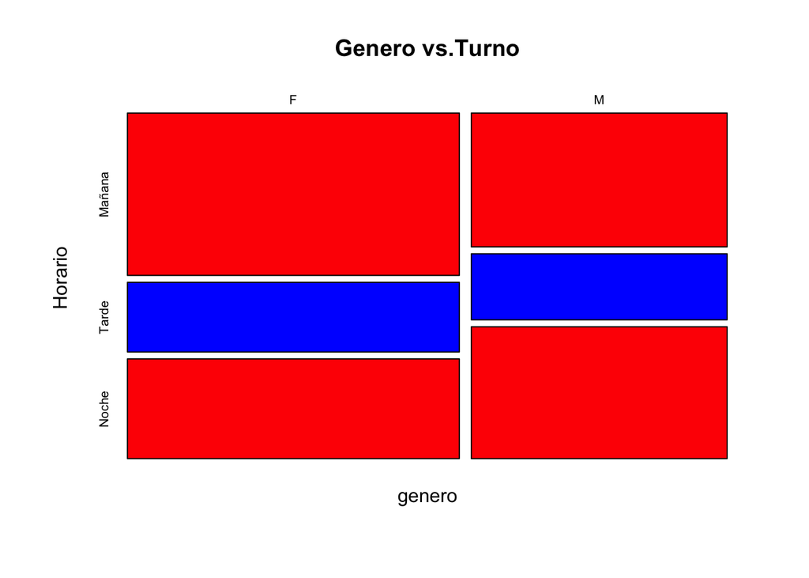

```r
plot(M, col = c("red", "blue"), main = "Genero vs.Turno")
```

# ¿Estas diferencias serán estadísticamente significativas? Utilizaremos la prueba de chi-cuadrado:

```r
chisq.test(M)
```

```
##
##  Pearson's Chi-squared test
##
## data:  M
## X-squared = 30.07, df = 2, p-value = 2.954e-07
```

# si se acepta la H0 entonces, los horarios de estudio son independietes del genero, o dicho de otra forma los dos agrupamientos son iguales

# si no puedo aceptar la H0 entonces, los horarios de estudio dependen del genero

```r
M <- as.table(rbind(c(81, 103, 147), c(359, 326, 277)))
dimnames(M) <- list(Obesidad= c("Obeso", "No_Obeso"),
      Estado_civil= c("Soltero","Pareja", "Casado"))
M
```

```
##           Estado_civil
## Obesidad   Soltero Pareja Casado
##   Obeso         81    103    147
##   No_Obeso     359    326    277
```

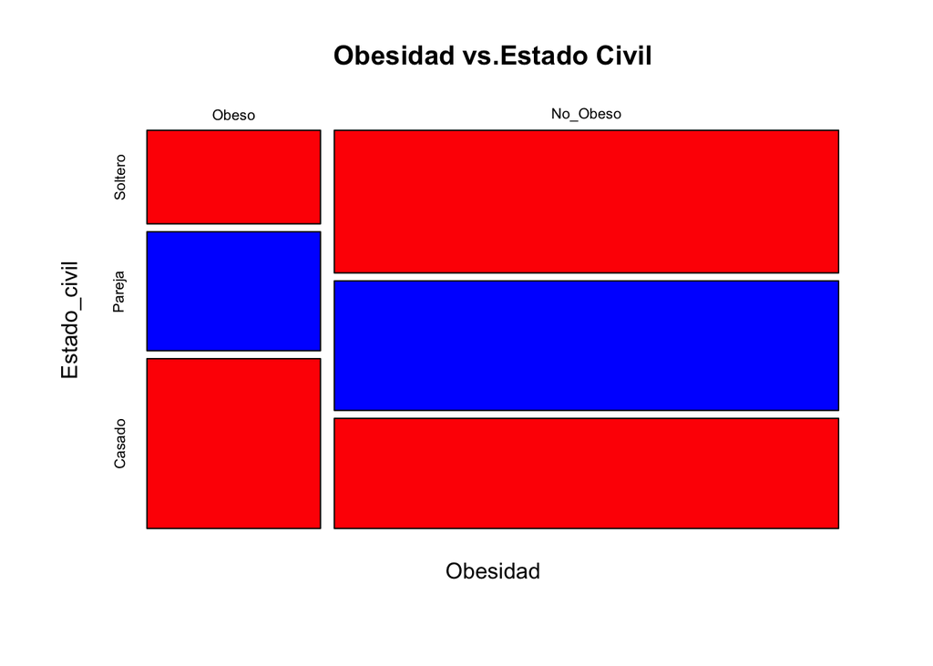

```r
plot(M, col = c("red", "blue"), main = "Obesidad vs.Estado Civil")
```

```r
chisq.test(M)
```

```
##
##  Pearson's Chi-squared test
##
## data:  M
## X-squared = 30.829, df = 2, p-value = 2.021e-07
```

# rechazo la hipotesis nula, con lo cual el grado de obesidad depende del estado civil de los individuos o las dos variables estan relacionadas.

```r
chisq.test(x = M)$residuals
```

```
##           Estado_civil
## Obesidad      Soltero     Pareja     Casado
##   Obeso    -2.9809729 -0.6509186  3.6914422
##   No_Obeso  1.7485759  0.3818151 -2.1653222
```

```r
chisq.test(x = M)$stdres
```

```
##           Estado_civil
## Obesidad      Soltero     Pareja     Casado
##   Obeso    -4.2549504 -0.9231681  5.2203206
##   No_Obeso  4.2549504  0.9231681 -5.2203206
```

```r
solteros_casados <- M[, c(1,3)]
solteros_casados
```

```
##           Estado_civil
## Obesidad   Soltero Casado
##   Obeso         81    147
##   No_Obeso     359    277
```

```r
chisq.test(solteros_casados)
```

```
##
##  Pearson's Chi-squared test with Yates' continuity correction
##
## data:  solteros_casados
## X-squared = 28.56, df = 1, p-value = 9.083e-08
```

```r
library("vcd")
```

Dado que el test de Fisher contrasta si las variables están relacionadas, al tamaño del efecto se le conoce como fuerza de asociación. Existen múltiples medidas de asociación, entre las que destacan phi o Cramer’s V. Los límites empleados para su clasificación son:

pequeño: 0.1 mediano: 0.3 grande: 0.5

```r
assocstats(solteros_casados)
```

```
##                     X^2 df   P(> X^2)
## Likelihood Ratio 29.687  1 5.0775e-08
## Pearson          29.391  1 5.9140e-08
##
## Phi-Coefficient   : 0.184
## Contingency Coeff.: 0.181
## Cramer's V        : 0.184
```

Se confirma que al menos entre los grupos casados y solteros sí hay una asociación significativa de las variables “estado civil” y “obesidad” con un tamaño de asociación Cramer’s V pequeño. Por lo tanto se puede afirmar que el porcentaje de gente obesa está asociado al estado civil.

### Ejemplo

### Se quiere estudiar si la reacción alérgica a un compuesto y una determinada mutación en un gen están relacionados. Para ello se realiza un test alérgico sobre un grupo de individuos seleccionados al azar y se genotipa el estado del gen de interés ¿Existe un diferencia significativa en la incidencia de la mutación entre los alérgicos y no alérgicos?

### Ejercicio: seleccione grupos de la muestra por VS y AM y determine si a) los dos grupos tiene la misma media para las MPG y los QSEC; b) El primer grupo tiene una media mayor que el segundo grupo para MPG y QSEC, c) los dos grupos tiene la misma varianza para MPG y QSEC; d) determine si las medias de MPG y QSEC pueden ser mayores a 30 y 20 respectivamente; e) determine la probabilidad del punto d); f) son las distribuciones de MPG y QSEC asimétricas para MPG y QSEC, en cada uno de los grupos; g) verifique la relación entre MPG y HP para cada uno de los grupo s e interprete los resultados (utilice un ggplot), podría indicar una ecuación para esa relación.

#### test de normalidad

```r
summary(iris)
```

```
##   Sepal.Length    Sepal.Width     Petal.Length    Petal.Width
##  Min.   :4.300   Min.   :2.000   Min.   :1.000   Min.   :0.100
##  1st Qu.:5.100   1st Qu.:2.800   1st Qu.:1.600   1st Qu.:0.300
##  Median :5.800   Median :3.000   Median :4.350   Median :1.300
##  Mean   :5.843   Mean   :3.057   Mean   :3.758   Mean   :1.199
##  3rd Qu.:6.400   3rd Qu.:3.300   3rd Qu.:5.100   3rd Qu.:1.800
##  Max.   :7.900   Max.   :4.400   Max.   :6.900   Max.   :2.500
##        Species
##  setosa    :50
##  versicolor:50
##  virginica :50
##
##
##
```

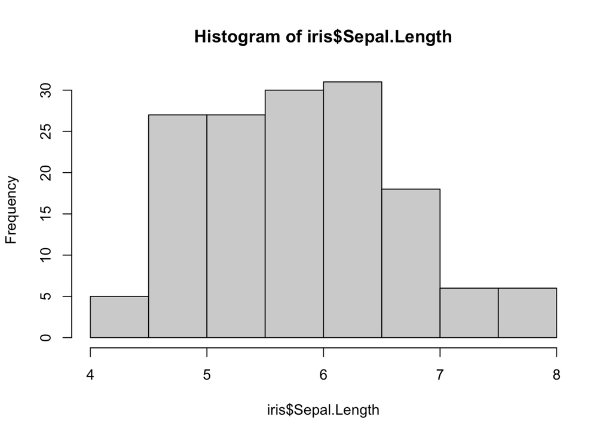

```r
hist(iris$Sepal.Length)
```

```r
shapiro.test(iris$Sepal.Length)
```

```
##
##  Shapiro-Wilk normality test
##
## data:  iris$Sepal.Length
## W = 0.97609, p-value = 0.01018
```

### Ejercicio:

- 1. tome su dataset con sus datos categoricos y trate de formular una hipotesis de independencia.
- 2. tome un grupo de variables continuas y arme grupos con aquellas variables mas correlacinadas
- 3. evalue la posibilidad de utilizar el test de Pearson
- 4. evalue la posibilidad de armar grupos de variables continuas con categoricas y establecer la independiencia

# Regresion

# Regresion logistica

Una de las principales aplicaciones de la regresión logística es la de clasificación binaria, en el que las observaciones se clasifican en un grupo u otro dependiendo del valor que tome la variable empleada como predictor. Por ejemplo, clasificar a un individuo desconocido como hombre o mujer en función del tamaño de la mandíbula.

Es importante tener en cuenta que, aunque la regresión logística permite clasificar, se trata de un modelo de regresión que modela el logaritmo de la probabilidad de pertenecer a cada grupo. La asignación final se hace en función de las probabilidades predichas.

[figure not shown]

### Que tipo de funciones tenemos para emular una probabilidad, como puede verse, un modelo lineal no es representativo del problema

[figure not shown]

### En nuestro caso, la variable dependiente o a explicar, es una variable del sistema pero no es la varable objetivo. Esto pude servir para mejorar nuestra conocimiento no condicional que surge del calculo de la frecuencia? Veamos que sucede.

# Los pasos que vamos a realizar son los siguiente:

- Separo los registros de los datos faltantes y construyo un set de datos
- Sobre el conjunto de datos que no tiene faltantes, armo un conjunto de entrenamiento y otro de testeo
- Aplicamos la funcion glm sobre los datos de z enfuncion de el resto de los datso del sistema
- Evaluo que tan bueno es nuestro ejercicio condicional con una matriz de confusion y comparo lo obtenido con el resultado no condicional
- Reemplazo los valores faltantes por los predichos y los convierto en categorias

### Hagamos una base con los datos faltantes de z y uno con los datos completos de z, al cual separaremos en dos.

```r
dfpred= dff[is.na(dff$z),]
dfpred
```

```
##           x1       x2  z         y
## 15  9.953185 209.0341 NA -102.6014
## 25 15.502253 235.3703 NA -138.6998
## 75 60.290886 263.6468 NA -139.8042
```

```r
dftoprove= dff[!is.na(dff$z),]
head(dftoprove)
```

```
##           x1       x2 z          y
## 1 -10.157242 194.9162 0 -104.71659
## 2   6.881486 207.6358 0  -99.11213
## 3  16.356783 228.2587 0 -123.92120
## 4  13.943691 195.0549 0  -82.08766
## 5 -14.761615 195.9196 0  -85.52401
## 6  12.040817 215.4871 0 -109.08803
```

### Ahora voy a separar el set de datos en test y train, esto es mas comun en modelos predictivos pero vamos a introducirlo de forma que vaya siendo lo mas natural posible.

```r
library(dplyr)
set.seed(1)

#create ID column
dftoprove$id <- 1:nrow(dftoprove)

#use 70% of dataset as training set and 30% as test set
train <- dftoprove %>% dplyr::sample_frac(0.70)
test  <- dplyr::anti_join(dftoprove, train, by = 'id')
```

```r
train=train[,(names(train)!="id")]
test=train[,(names(train)!="id")]
```

```r
logit=glm(z ~ x1 + x2 + y, data=train)
summary(logit)
```

```
##
## Call:
## glm(formula = z ~ x1 + x2 + y, data = train)
##
## Deviance Residuals:
##      Min        1Q    Median        3Q       Max
## -0.56677  -0.20956  -0.03626   0.21830   0.54653
##
## Coefficients:
##               Estimate Std. Error t value Pr(>|t|)
## (Intercept) -6.008e-01  5.164e-01  -1.164 0.248944
## x1           9.135e-03  2.589e-03   3.528 0.000781 ***
## x2           3.085e-03  2.488e-03   1.240 0.219551
## y            9.563e-06  5.830e-05   0.164 0.870222
## ---
## Signif. codes:  0 '***' 0.001 '**' 0.01 '*' 0.05 '.' 0.1 ' ' 1
##
## (Dispersion parameter for gaussian family taken to be 0.08817195)
##
##     Null deviance: 14.515  on 67  degrees of freedom
## Residual deviance:  5.643  on 64  degrees of freedom
## AIC: 33.717
##
## Number of Fisher Scoring iterations: 2
```

```r
test$pred=predict(object = logit,newdata = test)
test$predbin = (test$pred > 0.5) * 1


head(test)
```

```
##          x1       x2 z         y        pred predbin
## 1  78.19546 265.7590 1 -139.0271  0.93195694       1
## 2  62.77413 241.5933 1 -107.9305  0.71683121       1
## 3 -10.15724 194.9162 0 -104.7166 -0.09337556       0
## 4  33.34500 237.5361 0 -123.1799  0.43532514       0
## 5  73.24413 284.5712 1 5000.0000  0.99390068       1
## 6  48.94519 246.0002 1 -129.5916  0.60388596       1
```

```r
colnames(test)
```

```
## [1] "x1"      "x2"      "z"       "y"       "pred"    "predbin"
```

# como podemos comprar los resultados de este ejercicio

voy a usar una matriz de confusion, solo a los fines de ver si esta idea aumenta mis chances de inputar

Que es una matriz de confusion?

[figure not shown]

### Nos permite comprar los datos predichos de los observados en un ejercicio de testeo

```r
#install.packages('caret')
library(caret)
example <- confusionMatrix(as.factor(test$predbin), as.factor(test$z))
example
```

```
## Confusion Matrix and Statistics
##
##           Reference
## Prediction  0  1
##          0 20  2
##          1  1 45
##
##                Accuracy : 0.9559
##                  95% CI : (0.8764, 0.9908)
##     No Information Rate : 0.6912
##     P-Value [Acc > NIR] : 6.127e-08
##
##                   Kappa : 0.898
##
##  Mcnemar's Test P-Value : 1
##
##             Sensitivity : 0.9524
##             Specificity : 0.9574
##          Pos Pred Value : 0.9091
##          Neg Pred Value : 0.9783
##              Prevalence : 0.3088
##          Detection Rate : 0.2941
##    Detection Prevalence : 0.3235
##       Balanced Accuracy : 0.9549
##
##        'Positive' Class : 0
##
```

si este resultado es mejor que el que obtuvimos con la imputacion no condicionada, entonces hamos ganado algo de informacion.

apliquemoslo a nuestros datos

```r
which(is.na(dff$z))
```

```
## [1] 15 25 75
```

```r
dff[is.na(dff)]=predict(object = logit,newdata = dfpred)
```

```r
dff$z[dff$z>0.5] = 1
dff$z[dff$z<=0.5] = 0
head(dff)
```

```
##           x1       x2 z          y
## 1 -10.157242 194.9162 0 -104.71659
## 2   6.881486 207.6358 0  -99.11213
## 3  16.356783 228.2587 0 -123.92120
## 4  13.943691 195.0549 0  -82.08766
## 5 -14.761615 195.9196 0  -85.52401
## 6  12.040817 215.4871 0 -109.08803
```

```r
dff[c(15,25,75),]
```

```
##           x1       x2 z         y
## 15  9.953185 209.0341 0 -102.6014
## 25 15.502253 235.3703 0 -138.6998
## 75 60.290886 263.6468 1 -139.8042
```

```r
df[c(15,25,75),]
```

```
##           x        y
## 15 34.12743 29.60119
## 25 31.48443 23.93537
## 75 64.91672 54.20130
```

# Regresion lineal simple

$$\begin{equation}
\ y = \alpha + \beta_1*x_1i + \beta_2*x_2i + \beta_3*binaria_i +
\varepsilon_i
\end{equation}$$

$$\begin{equation}
\varepsilon_i \approx N(0,\sigma^2)
\end{equation}$$

# Función lm

```r
modelolin=lm(y ~ x1 + x2 + z, dff)
summary(modelolin)
```

```
##
## Call:
## lm(formula = y ~ x1 + x2 + z, data = dff)
##
## Residuals:
##    Min     1Q Median     3Q    Max
## -218.7  -93.8  -48.3    0.5 5048.4
##
## Coefficients:
##             Estimate Std. Error t value Pr(>|t|)
## (Intercept) -467.815    779.176  -0.600    0.550
## x1            -1.374      4.279  -0.321    0.749
## x2             1.730      3.797   0.456    0.650
## z             27.799    180.154   0.154    0.878
##
## Residual standard error: 521.5 on 96 degrees of freedom
## Multiple R-squared:  0.003911,   Adjusted R-squared:  -0.02722
## F-statistic: 0.1257 on 3 and 96 DF,  p-value: 0.9447
```

A continuación se presenta una corta descripción de los argumentos más usados en la función.

formula: es un objeto de la clase fórmula para indicar la variable respuesta y las covariables. Por ejemplo, si formula = y ~ x1 + x2 lo que se indica es que la variable respuesta es y, las covariables serían x1 y x2. data: es el marco de datos donde se buscarán las variables usadas en la fórmula. Si este parámetro queda vacío, R buscará las variables en el ambiente global.

Función predict

```r
dff$y[5]=NA
dff$y[50]=NA
dff$y[100]=NA
dff$y[90]=5000
```

```r
nuevo <- dff[c(5,50,100),]
```

```r
c(dff$y[5],dff$y[50],dff$y[90],dff$y[100])
```

```
## [1]   NA   NA 5000   NA
```

```r
predict(modelolin, newdata= nuevo)
```

```
##          5         50        100
## -108.60189  -86.61617  -94.03373
```

```r
dff[c(5,50,100),]
```

```
##            x1       x2 z  y
## 5   -14.76161 195.9196 0 NA
## 50   51.63464 245.2979 1 NA
## 100 132.59105 305.3140 1 NA
```

# Realice los siguientes pasos:

- Separo los registros de los datos faltantes y construyo un set de datos
- Sobre el conjunto de datos que no tiene faltantes, armo un conjunto de entrenamiento y otro de testeo
- Aplicamos la funcion glm sobre los datos de z enfuncion de el resto de los datso del sistema
- Evaluo que tan bueno es nuestro ejercicio condicional con una matriz de confusion y comparo lo obtenido con el resultado no condicional
- Reemplazo los valores faltantes por los predichos y los convierto en categorias